# Variables instrumentales - code Session 05

Carlos Daboín

5/18/2022

*Agradecimiento: Este tutorial se basa ampliamente en materiales preparados por Wendy Brau y Gastón Garcia, asistentes del Departamento de Economía de la Universidad de San Andrés (UDESA), cátedra de Econometría Avanzada*

# Librerias necesarias

```r
# *Agradecimiento: Este tutorial se basa ampliamente en materiales preparados por Wendy Brau y Gastón Garcia, asistentes del Departamento de Economía de la Universidad de San Andrés (UDESA), cátedra de Econometría Avanzada.*

# install.packages('AER')
# install.packages('tidyverse')

library(haven) # para abrir bases de datos en formato .dta
library(stargazer) # para tablas

library(tidyverse) # librer?a muy usada para manipular los datos y hacer gr?ficos
library(AER) # para usar el comando de variables instrumentales
```

# Caso 1. Retornos de la educación

¿Cúal es el efecto de un año mas de educación en los ingresos futuros de un joven? ¿Cúal es el efecto de terminar la educación secundaria, o incluso la universitaria?  
* No podemos hacer experimentos con decisiones tan importantes para las personas.  
* De nuevo, usar datos observacionales pudiera traernos problemas. ¿Por qué?  
* ¿Que tal si pudieramos encontrar grupos que se hayan salido o permanecido en el sistema educativo y que sean iguales en no observables (que los educados hubieran ganado lo mismo que los no educados de no ser por la educación)?

Revisaremos datos provenientes del siguiente estudio:  
* Angrist, Joshua D., and Alan B. Krueger. 1991. “Does Compulsory School Attendance Affect Schooling and Earnings?” Quarterly Journal of Economics 106 (4): 979–1014.

Premisa: Durante las décadas de 1930 y 1940 los jóvenes que alcanzaran los 16 años de edad durante la cursada del año escolar estaban en potestad de retirarse del sistema educativo. Aquellos jóvenes que nacen en los primeros trimestres del año tienen mayores chances de retirarse. Cómo no hay diferencias entre quienes nacen en los primeros trimestres y quienes nacen en los últimos trimestres, podemos usar el trimestre de nacimiento como instrumento.

## Generales

```r
# Limpio: (borro los elementos del environment)
rm(list=ls())

# Abro la base de datos:
qob_data <- read_dta("data/QOB.dta")

# Que variables tenemos
names(qob_data)
```

```
##  [1] "age"     "ageq"    "ageqsq"  "educ"    "lwage"   "married" "census"
##  [8] "qob"     "race"    "smsa"    "yob"
```

```r
# Estadisticas descriptivas generales
summary(qob_data)
```

```
##       age             ageq           ageqsq            educ
##  Min.   :30.00   Min.   :30.25   Min.   : 915.1   Min.   : 0.00
##  1st Qu.:33.00   1st Qu.:33.50   1st Qu.:1122.2   1st Qu.:12.00
##  Median :38.00   Median :38.00   Median :1444.0   Median :12.00
##  Mean   :38.49   Mean   :38.86   Mean   :1544.2   Mean   :13.25
##  3rd Qu.:43.00   3rd Qu.:43.75   3rd Qu.:1914.1   3rd Qu.:16.00
##  Max.   :50.00   Max.   :50.00   Max.   :2500.0   Max.   :20.00
##      lwage           married           census        qob
##  Min.   :-2.342   Min.   :0.0000   Min.   :80   Min.   :1.000
##  1st Qu.: 5.583   1st Qu.:1.0000   1st Qu.:80   1st Qu.:2.000
##  Median : 5.922   Median :1.0000   Median :80   Median :3.000
##  Mean   : 5.839   Mean   :0.8277   Mean   :80   Mean   :2.525
##  3rd Qu.: 6.186   3rd Qu.:1.0000   3rd Qu.:80   3rd Qu.:4.000
##  Max.   :11.225   Max.   :1.0000   Max.   :80   Max.   :4.000
##       race              smsa             yob
##  Min.   :0.00000   Min.   :0.0000   Min.   :30.00
##  1st Qu.:0.00000   1st Qu.:0.0000   1st Qu.:36.00
##  Median :0.00000   Median :0.0000   Median :42.00
##  Mean   :0.08166   Mean   :0.1858   Mean   :40.76
##  3rd Qu.:0.00000   3rd Qu.:0.0000   3rd Qu.:46.00
##  Max.   :1.00000   Max.   :1.0000   Max.   :49.00
```

Tras echarle un vistazo a la data, confirmamos que:  
* Los datos son a nivel individuo.  
* Los anos de nacimiento van de 1930 hasta 1949. * No hay variable género (creo que el estudio solo se realizó con varones). * No hay mucha diferencia entre las variables de edad y las variables de edad medidas en trimestres. Deberian ser un multiplo de 4. Hay algo raro en los datos, pero ignorémoslo por ahora.

## Tiene potencial como instrumento el trimestre de nacimiento ?

### Tabla

```r
# A.1 Cuadro con estad\'isticas descriptivas
stats<-qob_data %>%
  filter(yob >=30 & yob <=49) %>%
  mutate(decade=case_when(yob>=30 & yob<=39~"30's",
                          TRUE ~ "40's"),
         wage=exp(lwage)) %>%
  group_by(decade) %>%
  mutate(normalized_educ=(educ-mean(educ))/sd(educ),
         normalized_wage=(wage-mean(wage))/sd(wage)) %>%
  group_by(decade,qob) %>%
  summarise(mean_educ=mean(educ),
            educ_deviations_from_mean=mean(normalized_educ),
            mean_wage=mean(wage),
            wage_deviations_from_mean=mean(normalized_wage))

library(gt)
gt(stats) %>%
  tab_header(
    title = md("Anos de educacion promedio por trimestre de nacimiento")
  ) %>%
  gt::cols_label(
    decade="Decada",
    qob="Trimestre de nacimiento",
    mean_educ="Anos de educacion promedio",
    educ_deviations_from_mean = "Anos de educacion (desvios estandar de la media)",
    mean_wage="Salario promedio",
    wage_deviations_from_mean = "Salario (desvios estandar de la media)"
  )
```

Anos de educacion promedio por trimestre de nacimiento

| Trimestre de nacimiento | Anos de educacion promedio | Anos de educacion (desvios estandar de la media) | Salario promedio | Salario (desvios estandar de la media) |
| --- | --- | --- | --- | --- |
| 30's |  |  |  |  |
| 1 | 12.68807 | -0.024943796 | 436.1368 | -0.009135791 |
| 2 | 12.74472 | -0.007679051 | 438.5450 | -0.002537115 |
| 3 | 12.80541 | 0.010819482 | 441.2872 | 0.004976964 |
| 4 | 12.83943 | 0.021186874 | 441.8054 | 0.006397126 |
| 40's |  |  |  |  |
| 1 | 13.50922 | -0.020985507 | 391.5326 | 0.002042744 |
| 2 | 13.56706 | -0.001575777 | 391.4990 | 0.001952696 |
| 3 | 13.58315 | 0.003822970 | 391.8774 | 0.002969216 |
| 4 | 13.62326 | 0.017281713 | 388.2357 | -0.006815715 |

### Gráfico

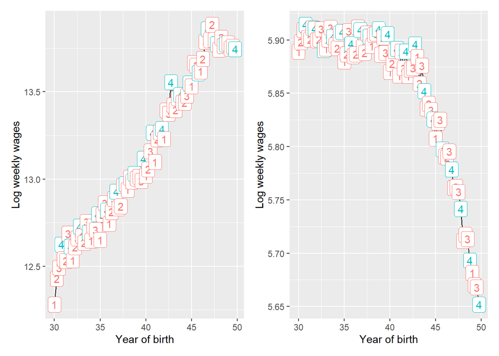

```r
# Summarize the average wages by age:
data_age <- qob_data %>%
  group_by(qob, yob) %>%
  summarise(lnw = mean(lwage), m_educ = mean(educ)) %>%
  mutate(q4 = (qob == 4)) %>%
  arrange( yob, qob)

p1<-ggplot(data_age, aes(x = yob + (qob - 1) / 4, y = m_educ)) +
      geom_line() +
      geom_label(mapping = aes(label = qob, color = q4)) +
      scale_x_continuous("Year of birth") +
      scale_y_continuous("Log weekly wages") +
      theme(legend.position = "none")

p2<-ggplot(data_age, aes(x = yob + (qob - 1) / 4, y = lnw)) +
      geom_line() +
      geom_label(mapping = aes(label = qob, color = q4)) +
      scale_x_continuous("Year of birth" ) +
      scale_y_continuous("Log weekly wages") +
      theme(legend.position = "none")
library(patchwork) #sirve para pegar graficas de lado a lado.
p1+p2
```

- El trimiestre de nacimiento tiene una correlacion positiva con el nivel de escolaridad promedio de los individuos de la muestra. Primeros trimestre tienen menos años de educación.
- El trimestre de nacimiento tiene una relación positiva con los salarios. Primeros trimestres tienen menor salario promedio.
- Las diferencias en el ingreso parecen desaparecer en la década de 1940. Es conveniente remover esta década del análisis

## Veamos los resultados de un OLS

```r
qob_data_30<-qob_data %>%
  filter(yob >=30 & yob <=39)

ols<-lm(lwage~educ + ageq+ageqsq+race+married+smsa, data=qob_data_30)

stargazer(ols, type="text",
          column.labels = c("OLS"),
          dep.var.labels=c("Log wage")
)
```

```
##
## ==================================================
##                          Dependent variable:
##                     ------------------------------
##                                Log wage
##                                  OLS
## --------------------------------------------------
## educ                           0.064***
##                                (0.0003)
##
## ageq                            -0.005
##                                (0.013)
##
## ageqsq                          0.0001
##                                (0.0001)
##
## race                          -0.269***
##                                (0.004)
##
## married                        0.243***
##                                (0.003)
##
## smsa                          -0.195***
##                                (0.003)
##
## Constant                       4.968***
##                                (0.293)
##
## --------------------------------------------------
## Observations                   329,509
## R2                              0.157
## Adjusted R2                     0.157
## Residual Std. Error      0.623 (df = 329502)
## F Statistic         10,211.540*** (df = 6; 329502)
## ==================================================
## Note:                  *p<0.1; **p<0.05; ***p<0.01
```

## Veamos los resultados para variables instrumentales

```r
qob_data_30<-qob_data_30 %>%
  mutate(z1=ifelse(qob==1,1,0),
         z2=ifelse(qob==2,1,0),
         z3=ifelse(qob==3,1,0))
```

### Test de instrumentos débiles

Se rechaza la hipotesis nula de que los trimestre tienen un impacto conjunto nulo sobre la variabilidad de la educación. Esto nos exenta del problema de instrumentos débiles.

```r
### F-test output: Recuerden que lo vimos en la primera clase
f_test<-lm(educ~z1+z2+z3, data = qob_data_30)

f_test%>%
  summary()
```

```
##
## Call:
## lm(formula = educ ~ z1 + z2 + z3, data = qob_data_30)
##
## Residuals:
##      Min       1Q   Median       3Q      Max
## -12.8394  -0.8394  -0.7447   2.1946   7.3119
##
## Coefficients:
##             Estimate Std. Error  t value Pr(>|t|)
## (Intercept) 12.83943    0.01154 1112.747  < 2e-16 ***
## z1          -0.15137    0.01628   -9.300  < 2e-16 ***
## z2          -0.09472    0.01635   -5.792 6.97e-09 ***
## z3          -0.03402    0.01603   -2.122   0.0339 *
## ---
## Signif. codes:  0 '***' 0.001 '**' 0.01 '*' 0.05 '.' 0.1 ' ' 1
##
## Residual standard error: 3.281 on 329505 degrees of freedom
## Multiple R-squared:  0.0003095,  Adjusted R-squared:  0.0003004
## F-statistic: 34.01 on 3 and 329505 DF,  p-value: < 2.2e-16
```

### Two stages IV and IV estimator

```r
### Output first stage
first_stage<-lm(educ~z1+z2+z3+ageq+ageqsq+race+married+smsa, data = qob_data_30)
summary(first_stage)
```

```
##
## Call:
## lm(formula = educ ~ z1 + z2 + z3 + ageq + ageqsq + race + married +
##     smsa, data = qob_data_30)
##
## Residuals:
##      Min       1Q   Median       3Q      Max
## -13.4756  -1.3435  -0.4232   2.1836  10.0074
##
## Coefficients:
##               Estimate Std. Error t value Pr(>|t|)
## (Intercept) 13.3265231  1.5097333   8.827  < 2e-16 ***
## z1          -0.0929991  0.0160124  -5.808 6.33e-09 ***
## z2          -0.0560659  0.0160484  -3.494 0.000477 ***
## z3          -0.0236291  0.0157050  -1.505 0.132438
## ageq         0.0507722  0.0671553   0.756 0.449625
## ageqsq      -0.0012665  0.0007443  -1.702 0.088799 .
## race        -1.7089366  0.0205686 -83.085  < 2e-16 ***
## married      0.1573927  0.0163607   9.620  < 2e-16 ***
## smsa        -1.1686623  0.0143963 -81.178  < 2e-16 ***
## ---
## Signif. codes:  0 '***' 0.001 '**' 0.01 '*' 0.05 '.' 0.1 ' ' 1
##
## Residual standard error: 3.212 on 329500 degrees of freedom
## Multiple R-squared:  0.04154,    Adjusted R-squared:  0.04152
## F-statistic:  1785 on 8 and 329500 DF,  p-value: < 2.2e-16
```

```r
### Output second stage

qob_data_30$educ_hat_over<-first_stage$fitted.values

second_stage_over<-lm(lwage~educ_hat_over+ ageq + ageqsq + race + married + smsa, data = qob_data_30)
```

```r
### Output IVreg

iv_fit <- ivreg(lwage ~ educ+ageq + ageqsq + race + married + smsa |
                  z1 + z2 + z3 + ageq + ageqsq + race + married + smsa ,
                data = qob_data_30)
```

### Resultados

```r
stargazer(first_stage,second_stage_over,iv_fit, type="text",
          column.labels = c("First stage", "Second stage", "Estimador IV"),
          dep.var.labels=c("Log wage")
          # ,
          # out="models_2sls.txt")
)
```

```
##
## ===================================================================================================
##                                                   Dependent variable:
##                     -------------------------------------------------------------------------------
##                               Log wage                                  lwage
##                                  OLS                           OLS                 instrumental
##                                                                                      variable
##                              First stage                  Second stage             Estimador IV
##                                  (1)                           (2)                      (3)
## ---------------------------------------------------------------------------------------------------
## z1                            -0.093***
##                                (0.016)
##
## z2                            -0.056***
##                                (0.016)
##
## z3                             -0.024
##                                (0.016)
##
## educ_hat_over                                               0.138***
##                                                              (0.033)
##
## educ                                                                                 0.138***
##                                                                                       (0.034)
##
## ageq                            0.051                        -0.009                   -0.009
##                                (0.067)                       (0.014)                  (0.014)
##
## ageqsq                         -0.001*                       0.0002                   0.0002
##                                (0.001)                      (0.0002)                 (0.0002)
##
## race                          -1.709***                     -0.143**                 -0.143**
##                                (0.021)                       (0.057)                  (0.057)
##
## married                       0.157***                      0.231***                 0.231***
##                                (0.016)                       (0.006)                  (0.006)
##
## smsa                          -1.169***                     -0.109***                -0.109***
##                                (0.014)                       (0.039)                  (0.039)
##
## Constant                      13.327***                     3.983***                 3.983***
##                                (1.510)                       (0.538)                  (0.547)
##
## ---------------------------------------------------------------------------------------------------
## Observations                   329,509                       329,509                  329,509
## R2                              0.042                         0.064                    0.035
## Adjusted R2                     0.042                         0.064                    0.035
## Residual Std. Error      3.212 (df = 329500)           0.657 (df = 329502)      0.667 (df = 329502)
## F Statistic         1,785.255*** (df = 8; 329500) 3,782.605*** (df = 6; 329502)
## ===================================================================================================
## Note:                                                                   *p<0.1; **p<0.05; ***p<0.01
```

# Caso 2. Salud infantil

¿Cúal es el efecto de tener padres/madres fumadores en la salud de sus hijos?

- No se puede responder experimentalmente por conflictos éticos claros.
- La data observacional nos dará estimados sesgados. ¿Por qué?
- ¿Qué pasaría si pudieramos aislar la variación en el hábito de fumar que está completamente aislada de las demás carácteristicas de los padres?

Revisaremos datos provenientes de los siguientes estudios:

- Currie, J. (2011). “Inequality at birth: Some causes and consequences”. American Economic Review: Papers Proceedings, 101(3), 1-22. Disponible en https://www.nber.org/papers/w16798
- Currie, J., Neidell, M. y Schmieder, J. (2008). “Air pollution and infant health: Lessons from New Jersey” NBER Working paper N? 14196. Disponible en https://www.nber.org/papers/w14196

Premisa: Los cambios en el consumo de cigarrillos motivados a la imposición de impuestos no tiene nada que ver con las otras conductas de los padres.

## Generales

```r
# Limpio: (borro los elementos del environment)
rm(list=ls())

# Abro la base de datos:
data <- read_dta("data/pesoalnacer.dta")

# Seteo 2 decimales y sin notaci?n cient?fica
options(scipen=100)
options(digits=2)

# Que variables tenemos
names(data)
```

```
##  [1] "cigtax"   "cigprice" "fatheduc" "motheduc" "parity"   "male"
##  [7] "white"    "lbwght"   "packs"    "lfaminc"
```

## Estadisticas descriptivas

Hagamos estadísticas descriptivas según lo aprendido en la primera clase. Emepcemos con comandos básicos de R, y después usemos comandos del tidyverse.

Pueden quedarse con la que mas les guste, pero creo que ya conocen mi manera favorita.

```r
# Lo mas basico
summary(data)
```

```
##      cigtax      cigprice      fatheduc      motheduc        parity
##  Min.   : 2   Min.   :104   Min.   : 1    Min.   : 2.0   Min.   :1.0
##  1st Qu.:15   1st Qu.:123   1st Qu.:12    1st Qu.:12.0   1st Qu.:1.0
##  Median :20   Median :131   Median :12    Median :12.0   Median :1.0
##  Mean   :20   Mean   :131   Mean   :13    Mean   :12.9   Mean   :1.6
##  3rd Qu.:26   3rd Qu.:137   3rd Qu.:16    3rd Qu.:14.0   3rd Qu.:2.0
##  Max.   :38   Max.   :152   Max.   :18    Max.   :18.0   Max.   :6.0
##                             NA's   :196   NA's   :1
##       male          white          lbwght        packs        lfaminc
##  Min.   :0.00   Min.   :0.00   Min.   :3.1   Min.   :0.0   Min.   :-0.7
##  1st Qu.:0.00   1st Qu.:1.00   1st Qu.:4.7   1st Qu.:0.0   1st Qu.: 2.7
##  Median :1.00   Median :1.00   Median :4.8   Median :0.0   Median : 3.3
##  Mean   :0.52   Mean   :0.78   Mean   :4.8   Mean   :0.1   Mean   : 3.1
##  3rd Qu.:1.00   3rd Qu.:1.00   3rd Qu.:4.9   3rd Qu.:0.0   3rd Qu.: 3.6
##  Max.   :1.00   Max.   :1.00   Max.   :5.6   Max.   :2.5   Max.   : 4.2
##
```

```r
# Agrupando por una variable categ?rica

# R base
aggregate(data, by=list(data$male), mean, na.rm=T)
```

```
##   Group.1 cigtax cigprice fatheduc motheduc parity male white lbwght packs
## 1       0     19      130       13       13    1.6    0  0.79    4.7   0.1
## 2       1     20      131       13       13    1.6    1  0.78    4.8   0.1
##   lfaminc
## 1     3.1
## 2     3.0
```

```r
aggregate(data[c('lbwght','motheduc')], by=list(data$male), mean, na.rm=T)
```

```
##   Group.1 lbwght motheduc
## 1       0    4.7       13
## 2       1    4.8       13
```

```r
### Par?ntesis:
### na.rm es un argumento para no considerar los NA al hacer el c?lculo
mean(c(1,2,NA,3))
```

```
## [1] NA
```

```r
mean(c(1,2,NA,3), na.rm=T)
```

```
## [1] 2
```

```r
# tidyverse
# Media de todas las variables por grupo:
data %>%
  group_by(male) %>%
  summarise_all(mean, na.rm=T)
```

```
## # A tibble: 2 x 10
##    male cigtax cigprice fatheduc motheduc parity white lbwght packs lfaminc
##   <dbl>  <dbl>    <dbl>    <dbl>    <dbl>  <dbl> <dbl>  <dbl> <dbl>   <dbl>
## 1     0   19.2     130.     13.2     12.9   1.65 0.794   4.75 0.105    3.11
## 2     1   19.9     131.     13.2     12.9   1.62 0.776   4.77 0.104    3.03
```

```r
# Mas especifico:
data %>%
  group_by(male) %>%
  summarise(peso = mean(lbwght, na.rm=T),
            peso_sd = var(lbwght, na.rm=T)  ) # podemos definir distintas funciones a aplicar a cada grupo
```

```
## # A tibble: 2 x 3
##    male  peso peso_sd
##   <dbl> <dbl>   <dbl>
## 1     0  4.75  0.0352
## 2     1  4.77  0.0372
```

```r
# Agrupo por precio de cigarrillo
data$caros <-  ifelse(data$cigprice>mean(data$cigprice), 'caros', 'baratos') # creo categorica a partir de numerica

data %>%
  group_by(male, caros) %>% # y agrupo por dos variables
  summarise(peso = mean(lbwght, na.rm=T),
            motheduc = mean(motheduc, na.rm=T))
```

```
## # A tibble: 4 x 4
## # Groups:   male [2]
##    male caros    peso motheduc
##   <dbl> <chr>   <dbl>    <dbl>
## 1     0 baratos  4.74     12.8
## 2     0 caros    4.76     13.1
## 3     1 baratos  4.78     12.8
## 4     1 caros    4.77     13.1
```

## Presentándolo en tablas resumen:

```r
### Podemos guardarlo en un objeto y usar stargazer con summary=FALSE para guardar la tabla
# Creemos tablas usando stargazer. Este es un paquete muy flexible para crear tabla, sobretodo para publicaciones impresas, como sus potenciales trabajos finales y/o tesis de grado.
tabla <-  data %>%
  group_by(male, caros) %>%
  summarise(peso = mean(lbwght, na.rm=T),
            educmadre = mean(motheduc, na.rm=T))
tabla
```

```
## # A tibble: 4 x 4
## # Groups:   male [2]
##    male caros    peso educmadre
##   <dbl> <chr>   <dbl>     <dbl>
## 1     0 baratos  4.74      12.8
## 2     0 caros    4.76      13.1
## 3     1 baratos  4.78      12.8
## 4     1 caros    4.77      13.1
```

```r
stargazer(tabla, type='text', summary = FALSE, digits = 2)
```

```
##
## ================================================
##   male  caros        peso          educmadre
## ------------------------------------------------
## 1  0   baratos 4.73817855682013 12.7760252365931
## 2  0    caros  4.75565684837979 13.0749279538905
## 3  1   baratos 4.77694859460819 12.7914110429448
## 4  1    caros  4.76746644481303 13.0604534005038
## ------------------------------------------------
```

### Repasemos como filtrar datos

```r
# Si queremos quedarnos con un subconjunto de los datos ----
data <- subset(data, lfaminc >= 0)

# Otra forma, con tidyverse
data <-  data %>%
  filter(lfaminc >= 0)
```

### Estimaciones - MCO vs VI

#### Minimos cuadrados ordinarios (MCO)

A continuación estimamos el efecto de la cantidad de cigarrillos fumados durante el embarazo sobre el peso del bebe al nacer.

- Interpreta coeficientes.
- Que problemas tendríamos para afirmar que encontramos un efecto causal?

```r
# MCO
lm.fit <- lm(lbwght ~ packs + male + parity + lfaminc, data=data)
summary(lm.fit) # logaritmo: 1 paquete afecta en x% al peso al nacer
```

```
##
## Call:
## lm(formula = lbwght ~ packs + male + parity + lfaminc, data = data)
##
## Residuals:
##     Min      1Q  Median      3Q     Max
## -1.6361 -0.0887  0.0209  0.1217  0.8411
##
## Coefficients:
##             Estimate Std. Error t value             Pr(>|t|)
## (Intercept)  4.66054    0.02430  191.79 < 0.0000000000000002 ***
## packs       -0.08626    0.01758   -4.91             0.000001 ***
## male         0.02512    0.01018    2.47              0.01374 *
## parity       0.01469    0.00573    2.56              0.01047 *
## lfaminc      0.02289    0.00639    3.58              0.00035 ***
## ---
## Signif. codes:  0 '***' 0.001 '**' 0.01 '*' 0.05 '.' 0.1 ' ' 1
##
## Residual standard error: 0.19 on 1364 degrees of freedom
## Multiple R-squared:  0.0373, Adjusted R-squared:  0.0345
## F-statistic: 13.2 on 4 and 1364 DF,  p-value: 0.000000000147
```

```r
stargazer(lm.fit, type="text")
```

```
##
## ===============================================
##                         Dependent variable:
##                     ---------------------------
##                               lbwght
## -----------------------------------------------
## packs                        -0.086***
##                               (0.018)
##
## male                          0.025**
##                               (0.010)
##
## parity                        0.015**
##                               (0.006)
##
## lfaminc                      0.023***
##                               (0.006)
##
## Constant                     4.700***
##                               (0.024)
##
## -----------------------------------------------
## Observations                   1,369
## R2                             0.037
## Adjusted R2                    0.034
## Residual Std. Error      0.190 (df = 1364)
## F Statistic          13.000*** (df = 4; 1364)
## ===============================================
## Note:               *p<0.1; **p<0.05; ***p<0.01
```

#### Metodo de variables instrumentales (IV)

Hagamos la estimación por método de variables instrumentales. Primero la haremos con el comando iv_reg, el cual es el recomendado. Despúes discutimos la manera de hacerlo a mano, para así sacar a relucir la importancia del supuesto de instrumentos fuertes.

```r
# IV
iv.fit <- ivreg(lbwght ~ packs + male + parity + lfaminc |
                  male + parity + lfaminc + cigprice, # instrumentos (cada variable ex?gena es su propio instrumento)
                data = data)
summary(iv.fit)
```

```
##
## Call:
## ivreg(formula = lbwght ~ packs + male + parity + lfaminc | male +
##     parity + lfaminc + cigprice, data = data)
##
## Residuals:
##     Min      1Q  Median      3Q     Max
## -2.2907 -0.0712  0.0797  0.1930  0.8950
##
## Coefficients:
##             Estimate Std. Error t value            Pr(>|t|)
## (Intercept)  4.41916    0.36907   11.97 <0.0000000000000002 ***
## packs        0.83868    1.40523    0.60                0.55
## male         0.03346    0.02178    1.54                0.12
## parity      -0.00325    0.02903   -0.11                0.91
## lfaminc      0.07768    0.08396    0.93                0.36
## ---
## Signif. codes:  0 '***' 0.001 '**' 0.01 '*' 0.05 '.' 0.1 ' ' 1
##
## Residual standard error: 0.33 on 1364 degrees of freedom
## Multiple R-Squared: -1.92,   Adjusted R-squared: -1.92
## Wald test: 2.46 on 4 and 1364 DF,  p-value: 0.0435
```

```r
#MC2E "a mano"
#First stage:
# Nota que lo se usa tanto el instrumento principal como todos los demas regresores.
first.stage <- lm(packs ~ cigprice + male + parity + lfaminc, data=data)

summary(first.stage)
```

```
##
## Call:
## lm(formula = packs ~ cigprice + male + parity + lfaminc, data = data)
##
## Residuals:
##     Min      1Q  Median      3Q     Max
## -0.3023 -0.1157 -0.0815 -0.0433  2.3607
##
## Coefficients:
##              Estimate Std. Error t value    Pr(>|t|)
## (Intercept)  0.182927   0.103741    1.76       0.078 .
## cigprice     0.000618   0.000768    0.80       0.421
## male        -0.009476   0.015685   -0.60       0.546
## parity       0.019440   0.008809    2.21       0.027 *
## lfaminc     -0.060019   0.009758   -6.15 0.000000001 ***
## ---
## Signif. codes:  0 '***' 0.001 '**' 0.01 '*' 0.05 '.' 0.1 ' ' 1
##
## Residual standard error: 0.29 on 1364 degrees of freedom
## Multiple R-squared:  0.0321, Adjusted R-squared:  0.0292
## F-statistic: 11.3 on 4 and 1364 DF,  p-value: 0.00000000504
```

```r
data$packs_hat <- first.stage$fitted.values

## Instrumentos dbiles Regla del pulgar
## Stock, J.H. & Watson M. (2011). Introduction to econometrics. 3rd Ed., Pearson Education.
## Stock J & Yogo M. (2005). Testing for Weak Instruments in Linear IV Regression. In:
##     Identification and Inference for Econometric Models. New York: Cambridge University Press. pp. 80-108.

#Segunda etapa:
second_stage <- lm(lbwght ~ packs_hat + male + parity + lfaminc, data = data)

#Juntemos todo:
stargazer(first.stage, second_stage, iv.fit, type="text",
          column.labels = c("First Stage", "Second Stage", "Estimador IV"),
          dep.var.labels=c("lbwght"), out="models_2sls.txt")
```

```
##
## =====================================================================
##                                          Dependent variable:
##                                 -------------------------------------
##                                   lbwght             lbwght
##                                     OLS         OLS      instrumental
##                                                            variable
##                                 First Stage Second Stage Estimador IV
##                                     (1)         (2)          (3)
## ---------------------------------------------------------------------
## cigprice                           0.001
##                                   (0.001)
##
## packs_hat                                      0.840
##                                               (0.810)
##
## packs                                                       0.840
##                                                            (1.400)
##
## male                              -0.009      0.033***      0.033
##                                   (0.016)     (0.013)      (0.022)
##
## parity                            0.019**      -0.003       -0.003
##                                   (0.009)     (0.017)      (0.029)
##
## lfaminc                          -0.060***     0.078        0.078
##                                   (0.010)     (0.049)      (0.084)
##
## Constant                          0.180*      4.400***     4.400***
##                                   (0.100)     (0.210)      (0.370)
##
## ---------------------------------------------------------------------
## Observations                       1,369       1,369        1,369
## R2                                 0.032       0.021        -1.900
## Adjusted R2                        0.029       0.018        -1.900
## Residual Std. Error (df = 1364)    0.290       0.190        0.330
## F Statistic (df = 4; 1364)       11.000***    7.300***
## =====================================================================
## Note:                                     *p<0.1; **p<0.05; ***p<0.01
```